# 2013 Grand Slams Tennis Data Interim Report

Önder Türe

2024-05-04

## 1. Brief Statement of the aim of the project

In this project, data is 4 different tennis singles 2013 grand slams match statistics. In the data, there are different statistics about match like foul, number of firs serve win, and others that will be explained in the next part. Aim of the project is predict the result of the tennis match by using different match statistics. Another aim is to find most effective match statistics for the win, and how is change for different tournament and gender. To reach this aim, firstly, data will be cleaned and tidied for the EDA and CDA. Then, explanatory data analysis will be done to see how data distributed and to interpret variables effectively. After EDA, missing values will be handled and data manipulation and feature engineering will be done if it is necessary. After data preparation is done, Confirmatory data analysis will be done by considering EDA. Finally, for statistical modeling to predict match result cross-validation techniques will be used. Finally, statistical modeling will be performed and performance of statistical modeling will be investigated.

## 2. Source of the data variables, dependent variable

Source of the data is [UC Irvine Machine Learning Repository](https://archive.ics.uci.edu/dataset/300/tennis+major+tournament+match+statistics). In the source of the data, there is 8 different csv file. Each one represent different tournament from 2013 (Aus Open-Men,AusOpen-Women, USOpen-men,…). Data has 4 different tournament group by gender, so we have 8 different csv file data. All of the 8 csv data has same 42 variables, so all of them are combined to 1 csv file and 2 variable added as tournament and gender. At the end, data has 44 variable. Dependent variable is ‘Result’. Our data have 943 match observations.

Variable Name and Definition

| Name of Variable | Definition of Variable |
| --- | --- |
| Player 1 | Name of Player 1 (Nominal) |
| Player 2 | Name of Player 2 (Nominal) |
| Round | Round of the tourneament (Nominal Ordinal) (1: 1st elimination round, 7: Final of the tournament ) |
| Result | Result of the match (0/1) - Referenced on Player 1 is Result = 1 (Nominal) |
| FSP.1 and .2 | First Serve Percentage for player 1 (if .2, player 2) (Integer) |
| FSW.1 and .2 | First Serve Won by player 1 (if .2, player 2) (Integer) |
| SSP.1 and .2 | Second Serve Percentage for player 1 (if .2, player 2) (Integer) |
| SSW.1 and .2 | Second Serve Won by player 1 (if .2, player 2) (Integer) |
| ACE.1 and .2 | Aces won by player 1 (if .2, player 2) (Integer) |
| DBF.1 and .2 | Double Faults committed by player 1 (if .2, player 2) (Integer) |
| WNR.1 and .2 | Winners earned by player 1 (if .2, player 2) (Integer) |
| UFE.1 and .2 | Unforced Errors committed by player 1 (if .2, player 2) (Integer) |
| BPC.1 and .2 | Break Points Created by player 1 (if .2, player 2) (Integer) |
| BPW.1 and .2 | Break Points Won by player 1 (if .2, player 2) (Integer) |
| NPA.1 and .2 | Net Points Attempted by player 1 (if .2, player 2) (Integer) |
| NPW.1 and .2 | Net Points Won by player 1 (if .2, player 2) (Integer) |
| TPW.1 and .2 | Total Points Won by player 1 (if .2, player 2) (Integer) |
| ST1.1 and .2 | Set 1 result for Player 1 (if .2, player 2) (Integer) |
| ST2.1 and .2 | Set 2 Result for Player 1 (if .2, player 2) (Integer) |
| ST3.1 and .2 | Set 3 Result for Player 1 (if .2, player 2) (Integer) |
| ST4.1 and .2 | Set 4 Result for Player 1 (if .2, player 2) (Integer) |
| ST5.1 and .2 | Set 5 Result for Player 1 (if .2, player 2) (Integer) |
| FNL.1 and .2 | Final Number of Games Won by Player 1 (if .2, player 2) (Integer) |
| tournament | Tournament name |
| gender | Tournament gender |

## 3. Data Cleaning and Tidying

Check variables and data types:

```
## 'data.frame':    943 obs. of  44 variables:
##  $ Player1   : chr  "Lukas Lacko" "Leonardo Mayer" "Marcos Baghdatis" "Dmitry Tursunov" ...
##  $ Player2   : chr  "Novak Djokovic" "Albert Montanes" "Denis Istomin" "Michael Russell" ...
##  $ Round     : int  1 1 1 1 1 1 1 1 1 1 ...
##  $ Result    : int  0 1 0 1 0 0 0 1 0 1 ...
##  $ FNL.1     : int  0 3 0 3 1 1 2 2 0 3 ...
##  $ FNL.2     : int  3 0 3 0 3 3 3 0 3 2 ...
##  $ FSP.1     : int  61 61 52 53 76 65 68 47 64 77 ...
##  $ FSW.1     : int  35 31 53 39 63 51 73 18 26 76 ...
##  $ SSP.1     : int  39 39 48 47 24 35 32 53 36 23 ...
##  $ SSW.1     : int  18 13 20 24 12 22 24 15 12 11 ...
##  $ ACE.1     : int  5 13 8 8 0 9 5 3 3 6 ...
##  $ DBF.1     : int  1 1 4 6 4 3 3 4 NA 4 ...
##  $ WNR.1     : int  17 13 37 8 16 35 41 21 20 6 ...
##  $ UFE.1     : int  29 1 50 6 35 41 50 31 39 4 ...
```

[output cut: 30 more lines]

Character values, “Round” and “Result” should be a factor. And name of the variables should be all upper or lower letter. So, all names of variables changed to upper letter.

Before change character values, “Round” and “Result” to factor let’s check head and tail of the data set.

Head and tail of the data:

| PLAYER1 | PLAYER2 | ROUND | RESULT | FNL.1 | FNL.2 | FSP.1 | FSW.1 | SSP.1 | SSW.1 | ACE.1 | DBF.1 | WNR.1 | UFE.1 | BPC.1 | BPW.1 | NPA.1 | NPW.1 | TPW.1 | ST1.1 | ST2.1 | ST3.1 | ST4.1 | ST5.1 | FSP.2 | FSW.2 | SSP.2 | SSW.2 | ACE.2 | DBF.2 | … |
| --- | --- | --- | --- | --- | --- | --- | --- | --- | --- | --- | --- | --- | --- | --- | --- | --- | --- | --- | --- | --- | --- | --- | --- | --- | --- | --- | --- | --- | --- | --- |
| Lukas Lacko | Novak Djokovic | 1 | 0 | 0 | 3 | 61 | 35 | 39 | 18 | 5 | 1 | 17 | 29 | 1 | 3 | 8 | 11 | 70 | 3 | 6 | 1 | NA | NA | 68 | 45 | 32 | 17 | 10 | 0 | … |
| Leonardo Mayer | Albert Montanes | 1 | 1 | 3 | 0 | 61 | 31 | 39 | 13 | 13 | 1 | 13 | 1 | 7 | 14 | NA | NA | 80 | 6 | 6 | 6 | NA | NA | 60 | 23 | 40 | 9 | 1 | 4 | … |
| Marcos Baghdatis | Denis Istomin | 1 | 0 | 0 | 3 | 52 | 53 | 48 | 20 | 8 | 4 | 37 | 50 | 1 | 9 | 16 | 23 | 106 | 4 | 5 | 4 | NA | NA | 77 | 57 | 23 | 15 | 9 | 1 | … |
| Dmitry Tursunov | Michael Russell | 1 | 1 | 3 | 0 | 53 | 39 | 47 | 24 | 8 | 6 | 8 | 6 | 6 | 9 | NA | NA | 104 | 6 | 6 | 6 | NA | NA | 50 | 24 | 50 | 19 | 1 | 8 | … |
| Juan Monaco | Ernests Gulbis | 1 | 0 | 1 | 3 | 76 | 63 | 24 | 12 | 0 | 4 | 16 | 35 | 3 | 12 | 9 | 13 | 128 | 6 | 4 | 6 | 2 | NA | 53 | 59 | 47 | 32 | 17 | 11 | … |
| Santiago Giraldo | Sam Querrey | 1 | 0 | 1 | 3 | 65 | 51 | 35 | 22 | 9 | 3 | 35 | 41 | 2 | 7 | 6 | 12 | 108 | 3 | 2 | 6 | 6 | NA | 63 | 60 | 37 | 22 | 24 | 4 | … |

|  | PLAYER1 | PLAYER2 | ROUND | RESULT | FNL.1 | FNL.2 | FSP.1 | FSW.1 | SSP.1 | SSW.1 | ACE.1 | DBF.1 | WNR.1 | UFE.1 | BPC.1 | BPW.1 | NPA.1 | NPW.1 | TPW.1 | ST1.1 | ST2.1 | ST3.1 | ST4.1 | ST5.1 | FSP.2 | FSW.2 | SSP.2 | SSW.2 | ACE.2 | … |
| --- | --- | --- | --- | --- | --- | --- | --- | --- | --- | --- | --- | --- | --- | --- | --- | --- | --- | --- | --- | --- | --- | --- | --- | --- | --- | --- | --- | --- | --- | --- |
| 938 | S.Stephens | M.Bartoli | 5 | 0 | 0 | 2 | 63 | 24 | 37 | 5 | 3 | 3 | 21 | 19 | 8 | 4 | 10 | 8 | NA | 4 | 5 | NA | NA | NA | 58 | 26 | 42 | 15 | 0 | … |
| 939 | A.Radwanska | N.Li | 5 | 1 | 2 | 1 | 77 | 52 | 23 | 9 | 0 | 5 | 32 | 18 | 16 | 5 | 32 | 21 | NA | 7 | 4 | 6 | NA | NA | 77 | 57 | 23 | 13 | 1 | … |
| 940 | S.Lisicki | K.Kanepi | 5 | 1 | 2 | 0 | 59 | 26 | 41 | 10 | 3 | 4 | 23 | 19 | 5 | 4 | 12 | 9 | NA | 6 | 6 | NA | NA | NA | 67 | 25 | 33 | 9 | 3 | … |
| 941 | M.Bartoli | K.Flipkens | 6 | 1 | 2 | 0 | 61 | 21 | 39 | 10 | 5 | 3 | 23 | 10 | 7 | 5 | 11 | 11 | NA | 6 | 6 | NA | NA | NA | 49 | 8 | 51 | 7 | 0 | … |
| 942 | S.Lisicki | A.Radwanska | 6 | 1 | 2 | 1 | 63 | 53 | 37 | 19 | 9 | 7 | 60 | 46 | 14 | 6 | 44 | 32 | NA | 6 | 2 | 9 | NA | NA | 70 | 42 | 30 | 15 | 1 | … |
| 943 | S.Lisicki | M.Bartoli | 7 | 0 | 0 | 2 | 65 | 22 | 35 | 9 | 6 | 5 | 21 | 25 | 8 | 2 | 18 | 11 | NA | 1 | 4 | NA | NA | NA | 67 | 31 | 33 | 7 | 2 | … |

As seen on the “PLAYER1” and “PLAYER2”, there is problem about how player names saved to data. In some rows player names saved as full name (first name + surname). However, in other rows, player names saved as shortened way like “M.Bartolli”. This problem fixed by convert all names shortened.

| PLAYER1 | PLAYER2 | ROUND | RESULT | FNL.1 | FNL.2 | FSP.1 | FSW.1 | SSP.1 | SSW.1 | ACE.1 | DBF.1 | WNR.1 | UFE.1 | BPC.1 | BPW.1 | NPA.1 | NPW.1 | TPW.1 | ST1.1 | ST2.1 | ST3.1 | ST4.1 | ST5.1 | FSP.2 | FSW.2 | SSP.2 | SSW.2 | ACE.2 | DBF.2 | … |
| --- | --- | --- | --- | --- | --- | --- | --- | --- | --- | --- | --- | --- | --- | --- | --- | --- | --- | --- | --- | --- | --- | --- | --- | --- | --- | --- | --- | --- | --- | --- |
| L.Lacko | N.Djokovic | 1 | 0 | 0 | 3 | 61 | 35 | 39 | 18 | 5 | 1 | 17 | 29 | 1 | 3 | 8 | 11 | 70 | 3 | 6 | 1 | NA | NA | 68 | 45 | 32 | 17 | 10 | 0 | … |
| L.Mayer | A.Montanes | 1 | 1 | 3 | 0 | 61 | 31 | 39 | 13 | 13 | 1 | 13 | 1 | 7 | 14 | NA | NA | 80 | 6 | 6 | 6 | NA | NA | 60 | 23 | 40 | 9 | 1 | 4 | … |
| M.Baghdatis | D.Istomin | 1 | 0 | 0 | 3 | 52 | 53 | 48 | 20 | 8 | 4 | 37 | 50 | 1 | 9 | 16 | 23 | 106 | 4 | 5 | 4 | NA | NA | 77 | 57 | 23 | 15 | 9 | 1 | … |
| D.Tursunov | M.Russell | 1 | 1 | 3 | 0 | 53 | 39 | 47 | 24 | 8 | 6 | 8 | 6 | 6 | 9 | NA | NA | 104 | 6 | 6 | 6 | NA | NA | 50 | 24 | 50 | 19 | 1 | 8 | … |
| J.Monaco | E.Gulbis | 1 | 0 | 1 | 3 | 76 | 63 | 24 | 12 | 0 | 4 | 16 | 35 | 3 | 12 | 9 | 13 | 128 | 6 | 4 | 6 | 2 | NA | 53 | 59 | 47 | 32 | 17 | 11 | … |
| S.Giraldo | S.Querrey | 1 | 0 | 1 | 3 | 65 | 51 | 35 | 22 | 9 | 3 | 35 | 41 | 2 | 7 | 6 | 12 | 108 | 3 | 2 | 6 | 6 | NA | 63 | 60 | 37 | 22 | 24 | 4 | … |

|  | PLAYER1 | PLAYER2 | ROUND | RESULT | FNL.1 | FNL.2 | FSP.1 | FSW.1 | SSP.1 | SSW.1 | ACE.1 | DBF.1 | WNR.1 | UFE.1 | BPC.1 | BPW.1 | NPA.1 | NPW.1 | TPW.1 | ST1.1 | ST2.1 | ST3.1 | ST4.1 | ST5.1 | FSP.2 | FSW.2 | SSP.2 | SSW.2 | ACE.2 | … |
| --- | --- | --- | --- | --- | --- | --- | --- | --- | --- | --- | --- | --- | --- | --- | --- | --- | --- | --- | --- | --- | --- | --- | --- | --- | --- | --- | --- | --- | --- | --- |
| 938 | S.Stephens | M.Bartoli | 5 | 0 | 0 | 2 | 63 | 24 | 37 | 5 | 3 | 3 | 21 | 19 | 8 | 4 | 10 | 8 | NA | 4 | 5 | NA | NA | NA | 58 | 26 | 42 | 15 | 0 | … |
| 939 | A.Radwanska | N.Li | 5 | 1 | 2 | 1 | 77 | 52 | 23 | 9 | 0 | 5 | 32 | 18 | 16 | 5 | 32 | 21 | NA | 7 | 4 | 6 | NA | NA | 77 | 57 | 23 | 13 | 1 | … |
| 940 | S.Lisicki | K.Kanepi | 5 | 1 | 2 | 0 | 59 | 26 | 41 | 10 | 3 | 4 | 23 | 19 | 5 | 4 | 12 | 9 | NA | 6 | 6 | NA | NA | NA | 67 | 25 | 33 | 9 | 3 | … |
| 941 | M.Bartoli | K.Flipkens | 6 | 1 | 2 | 0 | 61 | 21 | 39 | 10 | 5 | 3 | 23 | 10 | 7 | 5 | 11 | 11 | NA | 6 | 6 | NA | NA | NA | 49 | 8 | 51 | 7 | 0 | … |
| 942 | S.Lisicki | A.Radwanska | 6 | 1 | 2 | 1 | 63 | 53 | 37 | 19 | 9 | 7 | 60 | 46 | 14 | 6 | 44 | 32 | NA | 6 | 2 | 9 | NA | NA | 70 | 42 | 30 | 15 | 1 | … |
| 943 | S.Lisicki | M.Bartoli | 7 | 0 | 0 | 2 | 65 | 22 | 35 | 9 | 6 | 5 | 21 | 25 | 8 | 2 | 18 | 11 | NA | 1 | 4 | NA | NA | NA | 67 | 31 | 33 | 7 | 2 | … |

As seen on the head and tail of the data, data seems well tabulated data. There is no unnecessary columns. There is 0 duplicated observations in the data set. Player names fixed too.

Now character values, “Round” and “Result” can be changed to factor. And finalize structure of the data is below:

```
## 'data.frame':    943 obs. of  44 variables:
##  $ PLAYER1   : Factor w/ 308 levels "A.Barty","A.Beck",..: 161 162 169 70 126 252 68 85 62 205 ...
##  $ PLAYER2   : Factor w/ 309 levels "A.Barty","A.Beck",..: 213 22 69 205 82 260 139 4 237 167 ...
##  $ ROUND     : Factor w/ 7 levels "1","2","3","4",..: 1 1 1 1 1 1 1 1 1 1 ...
##  $ RESULT    : Factor w/ 2 levels "1","2": 2 1 2 1 2 2 2 1 2 1 ...
##  $ FNL.1     : int  0 3 0 3 1 1 2 2 0 3 ...
##  $ FNL.2     : int  3 0 3 0 3 3 3 0 3 2 ...
##  $ FSP.1     : int  61 61 52 53 76 65 68 47 64 77 ...
##  $ FSW.1     : int  35 31 53 39 63 51 73 18 26 76 ...
##  $ SSP.1     : int  39 39 48 47 24 35 32 53 36 23 ...
##  $ SSW.1     : int  18 13 20 24 12 22 24 15 12 11 ...
##  $ ACE.1     : int  5 13 8 8 0 9 5 3 3 6 ...
##  $ DBF.1     : int  1 1 4 6 4 3 3 4 NA 4 ...
##  $ WNR.1     : int  17 13 37 8 16 35 41 21 20 6 ...
##  $ UFE.1     : int  29 1 50 6 35 41 50 31 39 4 ...
```

[output cut: 30 more lines]

Also there is problem about BPC(Break Points Created) and BPW(Break Points Win). Logically, BPC must be greater or equal to BPW but in some rows BPC is lower than BPW like below example. This fixed by exchanging BPC values by BPW and BPW values by BPC when BPW > BPC.

```
##   BPC.1 BPW.1 BPC.2 BPW.2
## 1     1     3     4     8
## 2     7    14     0     0
## 3     1     9     4    13
## 4     6     9     1     7
## 5     3    12     3     5
## 6     2     7     4     7
```

There are similar problems with NPA and NPW for Aus open and French Open tournaments, NPA should be greater or equal to NPW. This fixed by exchanging NPA values by NPW and NPW values by NPA when NPW > NPA.

```
##   NPA.1 NPW.1 NPA.2 NPW.2
## 1     8    11     8     9
## 3    16    23    12    16
## 5     9    13    16    28
## 6     6    12    14    17
## 7    14    30    25    36
## 8     6     9     8    12
```

After fix the problem, all BPC values are greater than BPW. Same for NPA and NPW.

```
##   BPC.1 BPW.1 BPC.2 BPW.2
## 1     3     1     8     4
## 3     9     1    13     4
## 5    12     3     5     3
## 6     7     2     7     4
## 7    17     9    17    10
## 8    20     6     6     2
```

```
##   NPA.1 NPW.1 NPA.2 NPW.2
## 1    11     8     9     8
## 3    23    16    16    12
## 5    13     9    28    16
## 6    12     6    17    14
## 7    30    14    36    25
## 8     9     6    12     8
```

## 4. Explanatory Data Analysis(EDA) and Confirmatory Data Analysis(CDA)

### Summary Statistics

Below there are frequency tables for tournament, round, result and gender. Ausopen and French open tournaments have most number of match. Also, as expected most matches played at round 1. Number of male matches are greater than female matches. Moreover, Most round 1 matches played at US open, but at the remaining round US Open matches are not much when considering other tournaments. There can be incomplete data for US Open.

| Tournament | Freq |
| --- | --- |
| AusOpen | 253 |
| FrenchOpen | 252 |
| USopen | 202 |
| Wimbledon | 236 |

| Round | Freq |
| --- | --- |
| 1 | 536 |
| 2 | 197 |
| 3 | 107 |
| 4 | 55 |
| 5 | 27 |
| 6 | 14 |
| 7 | 7 |

| Result | Freq |
| --- | --- |
| 1 | 465 |
| 2 | 478 |

| Gender | Freq |
| --- | --- |
| F | 452 |
| M | 491 |

|  | 1 | 2 | 3 | 4 | 5 | 6 | 7 |
| --- | --- | --- | --- | --- | --- | --- | --- |
| AusOpen | 128 | 64 | 31 | 16 | 8 | 4 | 2 |
| FrenchOpen | 127 | 63 | 32 | 16 | 8 | 4 | 2 |
| USopen | 153 | 20 | 16 | 7 | 3 | 2 | 1 |
| Wimbledon | 128 | 50 | 28 | 16 | 8 | 4 | 2 |

Summary statistics for numeric variables are below. Avarage performances are almost equal for player 1 and player 2 statistics. Avarage performance of tennis players can be seen in this summary statistics.

```
##         PLAYER1           PLAYER2
##  S.Williams : 21   V.Azarenka : 18
##  N.Djokovic : 19   D.Ferrer   : 16
##  A.Radwanska: 17   M.Sharapova: 13
##  R.Nadal    : 14   R.Federer  : 13
##  J.Jankovic : 13   N.Li       : 12
##  A.Cornet   : 12   A.Ivanovic : 10
##  (Other)    :847   (Other)    :861
```

```
##      FSP.1           FSP.2           FSW.1            FSW.2
##  Min.   :38.00   Min.   : 0.00   Min.   :  3.00   Min.   :  0.00
##  1st Qu.:57.00   1st Qu.:57.00   1st Qu.: 26.00   1st Qu.: 25.00
##  Median :62.00   Median :62.00   Median : 37.00   Median : 36.00
##  Mean   :62.26   Mean   :61.97   Mean   : 38.79   Mean   : 38.69
##  3rd Qu.:67.00   3rd Qu.:67.00   3rd Qu.: 49.00   3rd Qu.: 48.50
##  Max.   :86.00   Max.   :93.00   Max.   :109.00   Max.   :132.00
```

```
##      SSP.1           SSP.2            SSW.1           SSW.2
##  Min.   :14.00   Min.   :  7.00   Min.   : 1.00   Min.   : 1.00
##  1st Qu.:33.00   1st Qu.: 33.00   1st Qu.:10.00   1st Qu.:10.00
##  Median :38.00   Median : 38.00   Median :15.00   Median :16.00
##  Mean   :37.79   Mean   : 38.05   Mean   :16.73   Mean   :16.93
##  3rd Qu.:43.00   3rd Qu.: 43.50   3rd Qu.:22.00   3rd Qu.:22.00
##  Max.   :62.00   Max.   :100.00   Max.   :52.00   Max.   :57.00
```

```
##      ACE.1           ACE.2            DBF.1            DBF.2
##  Min.   : 0.00   Min.   : 0.000   Min.   : 0.000   Min.   : 0.000
##  1st Qu.: 2.00   1st Qu.: 1.000   1st Qu.: 2.000   1st Qu.: 2.000
##  Median : 4.00   Median : 4.000   Median : 3.000   Median : 3.000
##  Mean   : 6.14   Mean   : 5.983   Mean   : 3.642   Mean   : 3.772
##  3rd Qu.: 8.00   3rd Qu.: 9.000   3rd Qu.: 5.000   3rd Qu.: 5.000
##  Max.   :41.00   Max.   :39.000   Max.   :18.000   Max.   :18.000
##  NA's   :22      NA's   :22       NA's   :8        NA's   :8
```

```
##      WNR.1            WNR.2          UFE.1           UFE.2
##  Min.   :  0.00   Min.   : 0.0   Min.   : 0.00   Min.   : 0.00
##  1st Qu.: 16.00   1st Qu.:16.0   1st Qu.:17.00   1st Qu.:16.00
##  Median : 25.00   Median :26.0   Median :26.00   Median :26.00
##  Mean   : 27.54   Mean   :27.8   Mean   :27.28   Mean   :27.68
##  3rd Qu.: 36.00   3rd Qu.:37.0   3rd Qu.:36.00   3rd Qu.:37.00
##  Max.   :111.00   Max.   :95.0   Max.   :89.00   Max.   :96.00
##  NA's   :126      NA's   :126    NA's   :126     NA's   :126
```

```
##      BPC.1            BPC.2            BPW.1            BPW.2
##  Min.   : 0.000   Min.   : 0.000   Min.   : 0.000   Min.   : 0.000
##  1st Qu.: 5.000   1st Qu.: 5.000   1st Qu.: 2.000   1st Qu.: 2.000
##  Median : 9.000   Median : 8.000   Median : 4.000   Median : 4.000
##  Mean   : 8.792   Mean   : 8.648   Mean   : 3.663   Mean   : 3.657
##  3rd Qu.:12.000   3rd Qu.:12.000   3rd Qu.: 5.000   3rd Qu.: 5.000
##  Max.   :28.000   Max.   :26.000   Max.   :11.000   Max.   :11.000
##  NA's   :1        NA's   :1        NA's   :1        NA's   :1
```

```
##      NPA.1           NPA.2           NPW.1           NPW.2
##  Min.   : 1.00   Min.   : 0.00   Min.   : 0.00   Min.   : 0.00
##  1st Qu.:10.00   1st Qu.:10.00   1st Qu.: 6.00   1st Qu.: 6.00
##  Median :17.00   Median :17.00   Median :11.00   Median :11.00
##  Mean   :19.85   Mean   :20.25   Mean   :12.86   Mean   :13.29
##  3rd Qu.:26.50   3rd Qu.:27.00   3rd Qu.:17.00   3rd Qu.:18.25
##  Max.   :96.00   Max.   :82.00   Max.   :62.00   Max.   :52.00
##  NA's   :84      NA's   :84      NA's   :83      NA's   :83
##      TPW.1            TPW.2
##  Min.   :  5.00   Min.   :  1.00
##  1st Qu.: 67.00   1st Qu.: 64.00
##  Median : 91.00   Median : 92.00
##  Mean   : 94.28   Mean   : 94.52
##  3rd Qu.:116.00   3rd Qu.:119.00
##  Max.   :231.00   Max.   :230.00
##  NA's   :312      NA's   :312
```

Also, set result summary is like below, as seen, there are a lot of NA values for ST4 and ST5 especially. This is because most of the match is not last to 5 or 4 set. It is over in 2 or 3 sets.

```r
sum8 <-GrandSlam %>%
  select(ST1.1,ST2.1,ST3.1,ST4.1,ST5.1)
sum9 <-GrandSlam %>%
  select(ST1.2,ST2.2,ST3.2,ST4.2,ST5.2)
summary(sum8)
```

```
##      ST1.1           ST2.1           ST3.1           ST4.1
##  Min.   :0.000   Min.   :0.000   Min.   :0.000   Min.   :0.000
##  1st Qu.:3.000   1st Qu.:4.000   1st Qu.:3.000   1st Qu.:3.000
##  Median :6.000   Median :6.000   Median :6.000   Median :6.000
##  Mean   :4.801   Mean   :4.781   Mean   :4.728   Mean   :4.787
##  3rd Qu.:6.000   3rd Qu.:6.000   3rd Qu.:6.000   3rd Qu.:6.000
##  Max.   :7.000   Max.   :7.000   Max.   :9.000   Max.   :7.000
##  NA's   :1       NA's   :4       NA's   :321     NA's   :722
##      ST5.1
##  Min.   :0.000
##  1st Qu.:3.000
##  Median :5.000
##  Mean   :4.651
##  3rd Qu.:6.000
##  Max.   :9.000
##  NA's   :857
```

```r
summary(sum9)
```

```
##      ST1.2           ST2.2           ST3.2           ST4.2          ST5.2
##  Min.   :0.000   Min.   :0.000   Min.   :0.000   Min.   :0.00   Min.   :1.000
##  1st Qu.:3.000   1st Qu.:3.000   1st Qu.:3.000   1st Qu.:3.00   1st Qu.:4.000
##  Median :6.000   Median :6.000   Median :6.000   Median :6.00   Median :6.000
##  Mean   :4.816   Mean   :4.695   Mean   :4.823   Mean   :4.71   Mean   :5.128
##  3rd Qu.:6.000   3rd Qu.:6.000   3rd Qu.:6.000   3rd Qu.:6.00   3rd Qu.:6.000
##  Max.   :7.000   Max.   :7.000   Max.   :9.000   Max.   :7.00   Max.   :9.000
##  NA's   :1       NA's   :4       NA's   :321     NA's   :722    NA's   :857
```

### Research Questions

#### How does number of break points win (BPW) and break points created (BPC) corralete between 2 player according to result?

As seen in the scatter plot, there is correlation between result and break points win. If player has more break points than opponent player, then, player that has more BPW and BPC probably win the match.

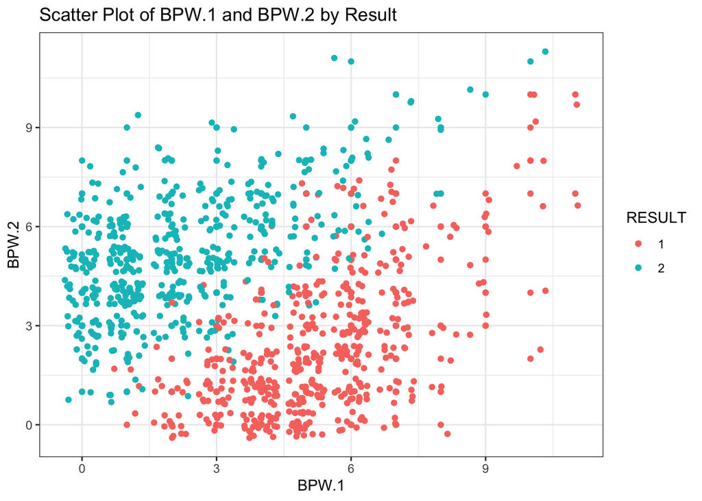

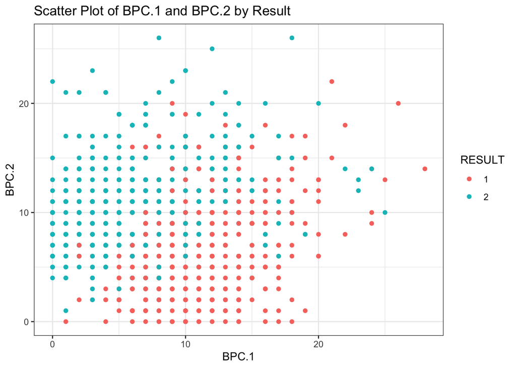

Hypothesis t-test can be conduct to show avarage BPC or BPW is greater for winning player.

```
##
##  Two Sample t-test
##
## data:  BPC.1.P1win and BPC.2.P1win
## t = 16.758, df = 928, p-value < 2.2e-16
## alternative hypothesis: true difference in means is greater than 0
## 95 percent confidence interval:
##  4.285722      Inf
## sample estimates:
## mean of x mean of y
## 11.210753  6.458065
```

H0 is BPC.1 is equal or less than BPC.2 for RESULT is equals 1. H1 is BPC.1 is greater than BPC.2 for RESULT is equals 1. From t test confidence interval is 4.2857224, to infinite. So we can reject null hypothesis. Mean of BPC.1 is greater than mean of BPC.2 for RESULT equals 1. Similarly, mean of BPW.1 is greater than mean of BPW.2 for RESULT equals 1 according to t-test.

```
##
##  Two Sample t-test
##
## data:  BPC.1.P1win and BPC.2.P1win
## t = 16.758, df = 928, p-value < 2.2e-16
## alternative hypothesis: true difference in means is greater than 0
## 95 percent confidence interval:
##  4.285722      Inf
## sample estimates:
## mean of x mean of y
## 11.210753  6.458065
```

```
##
##  Two Sample t-test
##
## data:  BPW.1.P1win and BPW.2.P1win
## t = 24.486, df = 928, p-value < 2.2e-16
## alternative hypothesis: true difference in means is greater than 0
## 95 percent confidence interval:
##  2.752139      Inf
## sample estimates:
## mean of x mean of y
##  5.165591  2.215054
```

This situation is valid for RESULT equals 2 too.

```
##
##  Two Sample t-test
##
## data:  BPC.2.P2win and BPC.1.P2win
## t = 14.982, df = 952, p-value < 2.2e-16
## alternative hypothesis: true difference in means is greater than 0
## 95 percent confidence interval:
##  3.870193      Inf
## sample estimates:
## mean of x mean of y
## 10.781971  6.433962
```

```
##
##  Two Sample t-test
##
## data:  BPW.2.P2win and BPW.1.P2win
## t = 24.587, df = 952, p-value < 2.2e-16
## alternative hypothesis: true difference in means is greater than 0
## 95 percent confidence interval:
##  2.671964      Inf
## sample estimates:
## mean of x mean of y
##  5.062893  2.199161
```

#### How does change distribution of first serve percentage (FSP) and First serve winning (FSW) for winning and losing player?

As seen on the density plot, when player win the match, player’s first serve percentage is increase. Therefore, first serve percentage can be effective for winning the match. Similarly, box plot of FSP show that winner player has more FSW than loser one. So, having more FSW can effect the result.

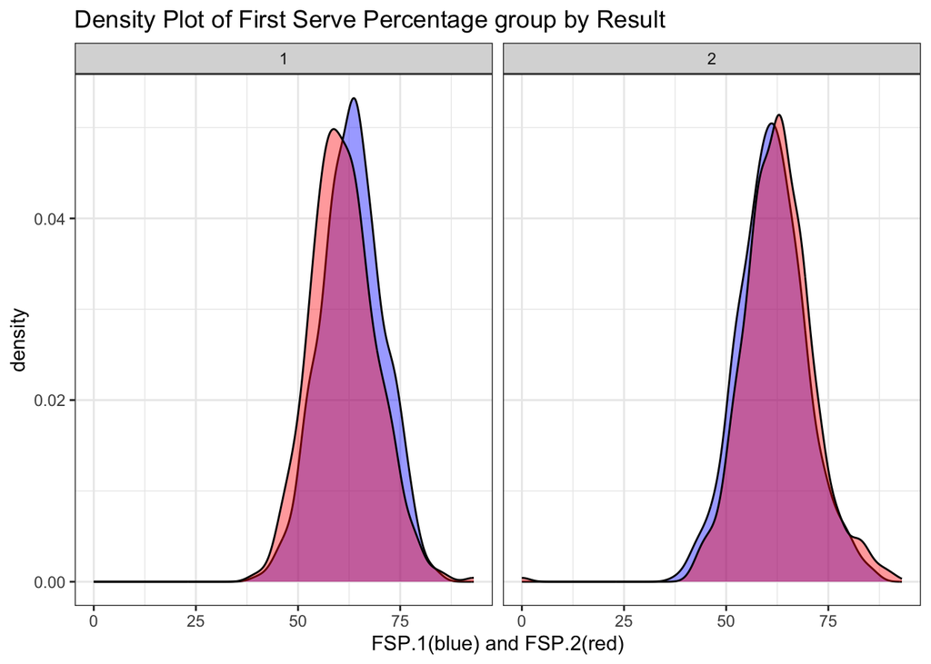

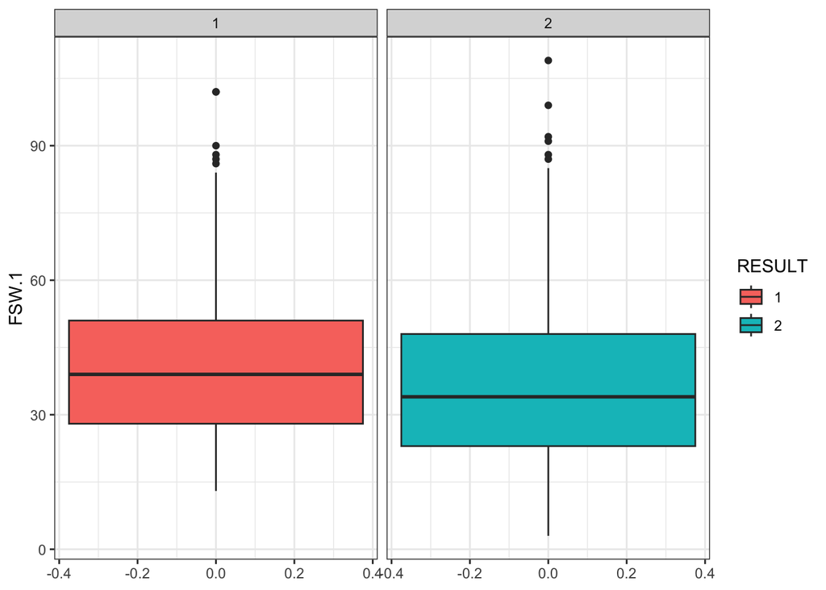

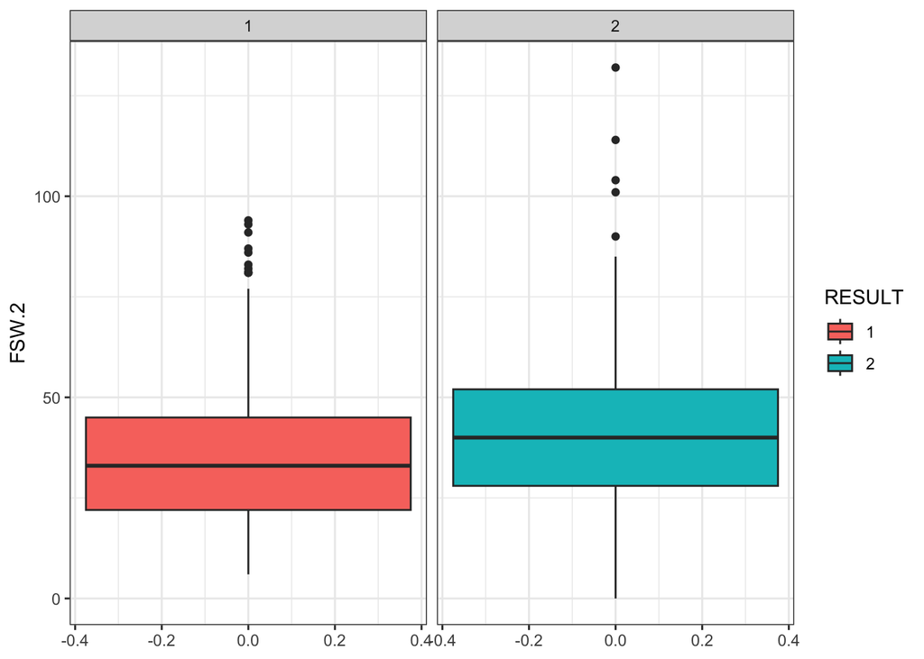

For confirmatory data analysis for this reasearch question, two paired t-test can be conduct too. As seen on the t-test result, mean of FSP.1 is changed significantly when result change.

```
## [1] "Two-sample t-test for First Serve Percentage (FSP.1):"
```

```
##
##  Two Sample t-test
##
## data:  fsp1_P1win and fsp1_P2win
## t = 3.756, df = 941, p-value = 0.0001833
## alternative hypothesis: true difference in means is not equal to 0
## 95 percent confidence interval:
##  0.9190557 2.9303976
## sample estimates:
## mean of x mean of y
##  63.23226  61.30753
```

```
## [1] "Two-sample t-test for First Serve Winning (FSW.1):"
```

```
##
##  Two Sample t-test
##
## data:  fsw1_P1win and fsw1_P2win
## t = 3.6426, df = 941, p-value = 0.0002847
## alternative hypothesis: true difference in means is not equal to 0
## 95 percent confidence interval:
##  1.901268 6.342994
## sample estimates:
## mean of x mean of y
##  40.87527  36.75314
```

t-tests for FSP.2 and FSW.2 are like FSP.1 and FSP.2

```
## [1] "Two-sample t-test for First Serve Percentage (FSP.2):"
```

```
##
##  Two Sample t-test
##
## data:  fsp2_P1win and fsp2_P2win
## t = -2.9031, df = 941, p-value = 0.003781
## alternative hypothesis: true difference in means is not equal to 0
## 95 percent confidence interval:
##  -2.6430882 -0.5109677
## sample estimates:
## mean of x mean of y
##  61.16774  62.74477
```

```
## [1] "Two-sample t-test for First Serve Winning (FSW.2):"
```

```
##
##  Two Sample t-test
##
## data:  fsw2_P1win and fsw2_P2win
## t = -5.1976, df = 941, p-value = 2.476e-07
## alternative hypothesis: true difference in means is not equal to 0
## 95 percent confidence interval:
##  -8.065531 -3.644237
## sample estimates:
## mean of x mean of y
##  35.72043  41.57531
```

#### How does distribution of number of double faul (DBF) and aces (ACE) change for different tournaments grouped by gender?

On this part, ACE variable is created by summing of ACE.1 and ACE.2. Similarly other variables are summing and total of player 1 and player 2 statistic variables are created. Aim of this research is investigating effect of different tournament on player performance. Each tournament have different surface type so this should be effect the match statistics. As seen in the boxplots, at French open tournament, players do less ace than other tounaments. Clay surface (French open surface) can lead to this, because clay surface slow down the ball. Also, in the boxplot of DBF, we can say that players do more double foul at the US and AUS open tournaments. Both tournaments has hard surfaces. Additionally, there is significant diffrence on male and female statistics for ACE, male can do more ACE than womwn according to this graph but number of sets are not same for male and female matches. Female matches are best of 3, but male matches are best of 5. So, this can be reason for that.

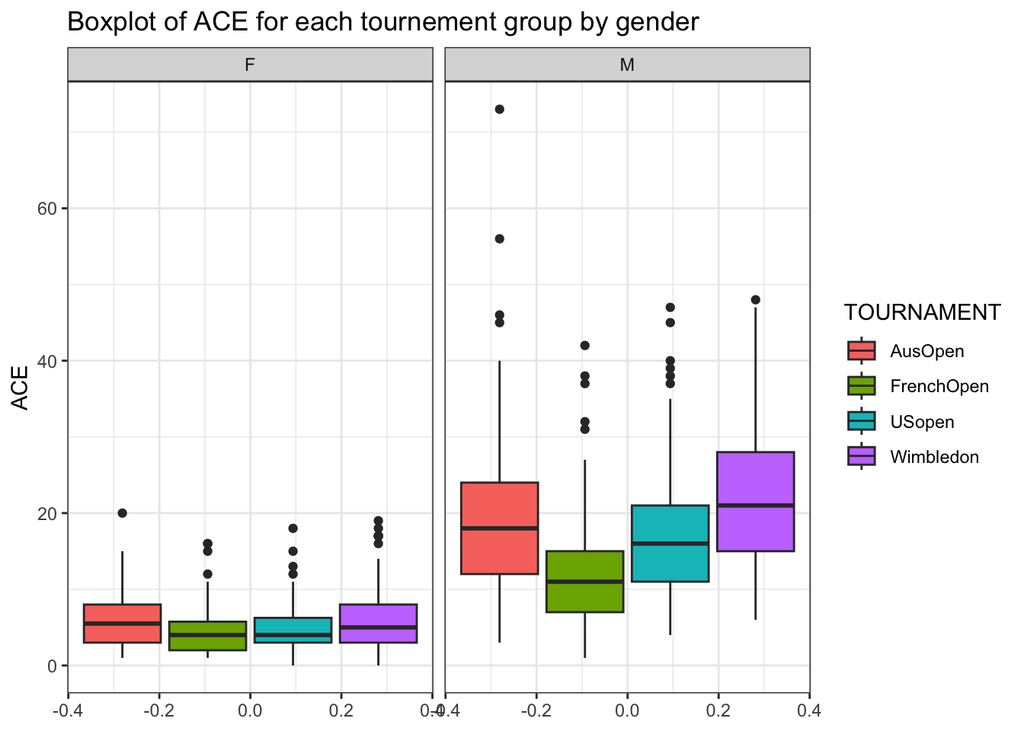

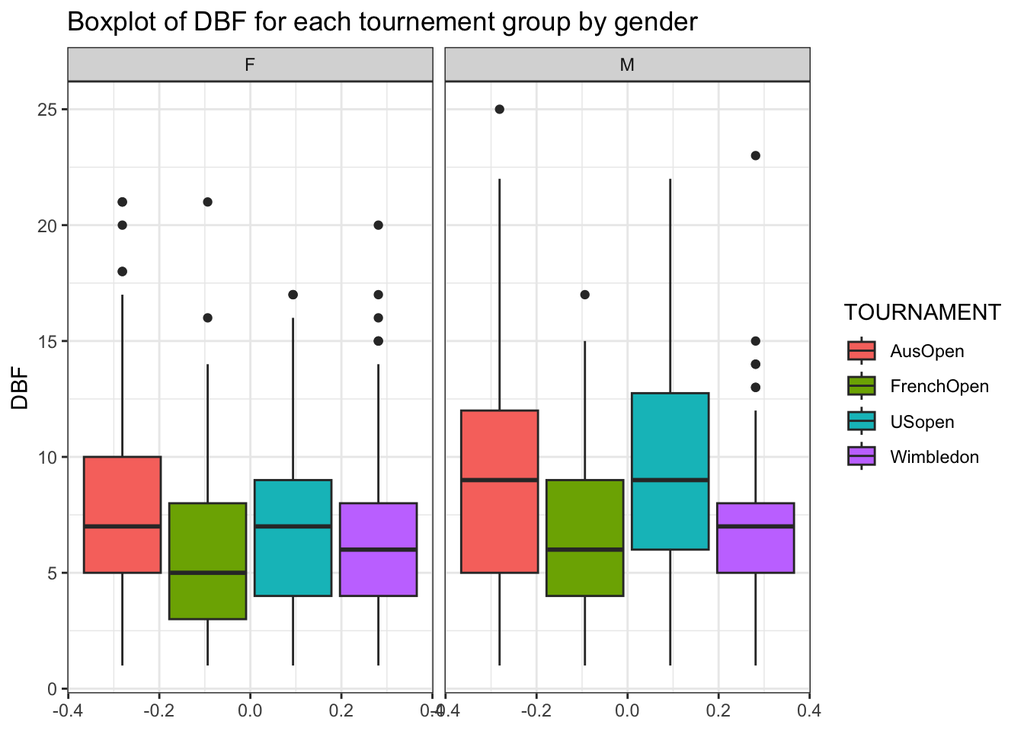

With analysis of variance (ANOVA) for DBF and ACE, We can see there are significant difference between tournaments and gender for 0.05 significance level.

```
## [1] "ANAVO of DBF"
```

```
##              Df Sum Sq Mean Sq F value   Pr(>F)
## TOURNAMENT    3   1134   378.1   24.13 4.82e-15 ***
## GENDER        1    310   310.0   19.78 9.72e-06 ***
## Residuals   930  14572    15.7
## ---
## Signif. codes:  0 '***' 0.001 '**' 0.01 '*' 0.05 '.' 0.1 ' ' 1
## 8 observations deleted due to missingness
```

```
## [1] "ANAVO of ACE"
```

```
##              Df Sum Sq Mean Sq F value   Pr(>F)
## TOURNAMENT    3   4114    1371    24.5 2.96e-15 ***
## GENDER        1  36744   36744   656.5  < 2e-16 ***
## Residuals   916  51265      56
## ---
## Signif. codes:  0 '***' 0.001 '**' 0.01 '*' 0.05 '.' 0.1 ' ' 1
## 22 observations deleted due to missingness
```

#### Are there differences in the net points attempt (NPA) and net points win (NPW) by players across different rounds of the tournament by result?

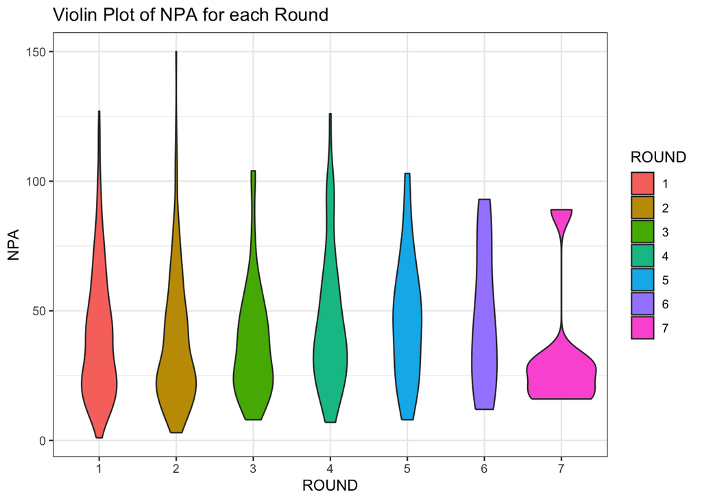

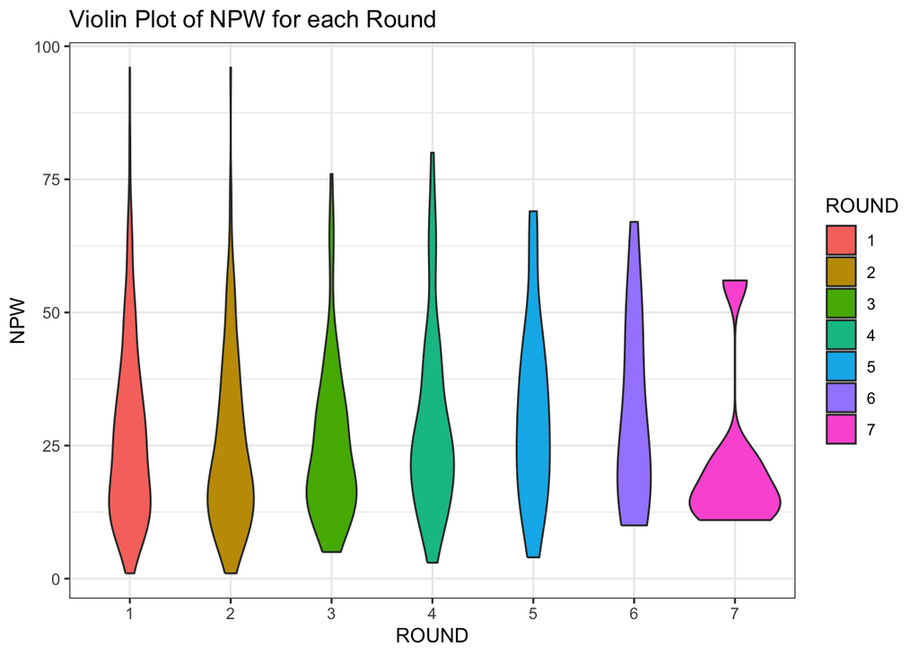

Again by using ANOVA, we can show there is significant difference or not in NPW and NPA. As seen in ANOVA, for 0.05 significance level, there is no significant difference between NPA and NPW observations of different rounds.

```
## [1] "ANAVO of NPA"
```

```
##              Df Sum Sq Mean Sq F value Pr(>F)
## ROUND         6   5553   925.5   1.558  0.156
## Residuals   852 506175   594.1
## 84 observations deleted due to missingness
```

```
## [1] "ANAVO of NPW"
```

```
##              Df Sum Sq Mean Sq F value Pr(>F)
## ROUND         6   2253   375.6   1.453  0.191
## Residuals   853 220433   258.4
## 83 observations deleted due to missingness
```

#### Is there any correlation between number of break points created (BPC), total points win (TPW) and first serve win (FSW)?

As seen on bubble plot, whwn BPC increase, TPW increase because when player break the opponent player serve, match can be extend. Also number of first serve win tend to increase when TPW and BPC increase.

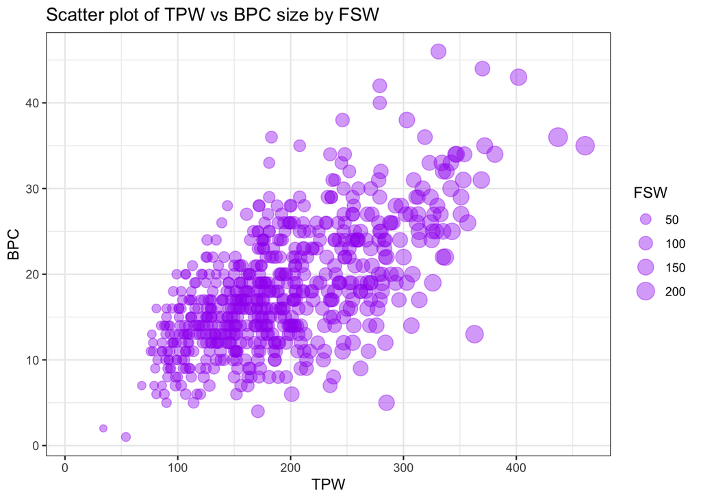

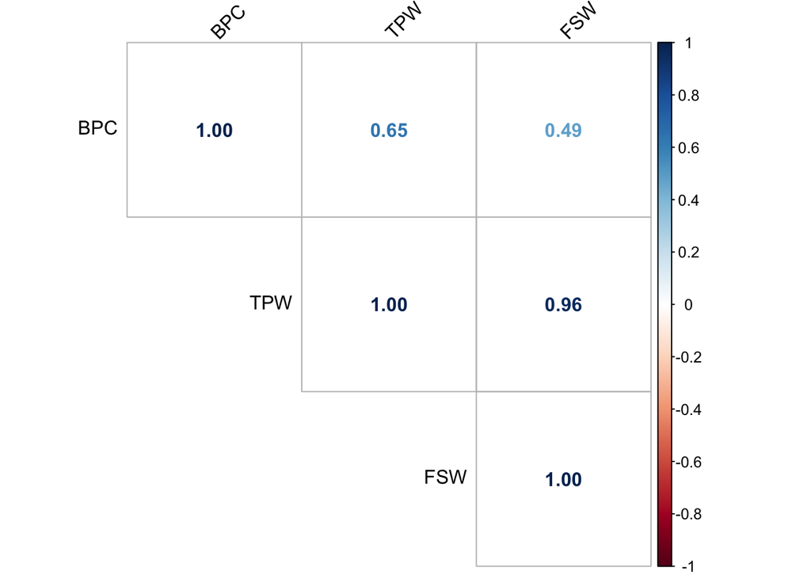

Also, checking p values of correlation test show that there is significant correlation between BPC, TPW and FSW for 0.05 significance level.

```
##   cor_test     p_values
## 1  BPC_TPW 4.643419e-76
## 2  BPC_FSW 1.610577e-49
## 3  TPW_FSW 0.000000e+00
```

## 5. Missing Observation Cleaning, Imputation and Data Manipulation

Firstly, we should find NA values. As we look at the number of NA observations of variables that include NA (below), we can see there are 5338 NA values

```
## FNL.1 FNL.2 ACE.1 DBF.1 WNR.1 UFE.1 BPC.1 BPW.1 NPA.1 NPW.1 TPW.1 ST1.1 ST2.1
##     1     1    22     8   126   126     1     1    84    83   312     1     4
## ST3.1 ST4.1 ST5.1 ACE.2 DBF.2 WNR.2 UFE.2 BPC.2 BPW.2 NPA.2 NPW.2 TPW.2 ST1.2
##   321   722   857    22     8   126   126     1     1    84    83   312     1
## ST2.2 ST3.2 ST4.2 ST5.2
##     4   321   722   857
```

For, FNL.1 and FNL.2 NA values are because of cancelled match. At the [link](https://www.tennisabstract.com/cgi-bin/wplayer-classic.cgi?p=AlizeCornet&f=A2014qqC2), you can see this match (date 13.01.2014) is cancelled. This row is removed from data set.

```
##    PLAYER1  PLAYER2 ROUND RESULT FNL.1 FNL.2 FSP.1 FSW.1 SSP.1 SSW.1 ACE.1
## 1 A.Cornet P.Hercog     1      2    NA    NA    75     3    25     1     1
##   DBF.1 WNR.1 UFE.1 BPC.1 BPW.1 NPA.1 NPW.1 TPW.1 ST1.1 ST2.1 ST3.1 ST4.1 ST5.1
## 1    NA     2     0    NA    NA     1     1     5    NA    NA    NA    NA    NA
##   FSP.2 FSW.2 SSP.2 SSW.2 ACE.2 DBF.2 WNR.2 UFE.2 BPC.2 BPW.2 NPA.2 NPW.2 TPW.2
## 1     0     0   100     1     0    NA     1     1    NA    NA     0     0     1
##   ST1.2 ST2.2 ST3.2 ST4.2 ST5.2 TOURNAMENT GENDER
## 1    NA    NA    NA    NA    NA    AusOpen      F
```

After removing the row that FNL values NA:

```
## ACE.1 DBF.1 WNR.1 UFE.1 NPA.1 NPW.1 TPW.1 ST2.1 ST3.1 ST4.1 ST5.1 ACE.2 DBF.2
##    22     7   126   126    84    83   312     3   320   721   856    22     7
## WNR.2 UFE.2 NPA.2 NPW.2 TPW.2 ST2.2 ST3.2 ST4.2 ST5.2
##   126   126    84    83   312     3   320   721   856
```

There is 22 NA in ACE.1 and ACE.2 columns at same observations, this is MCAR type missing observations, we can fill this values by median value of ACE. Median of ACE.1 and ACE.2 are 4 and 4.

```
##             PLAYER1          PLAYER2 ROUND RESULT FNL.1 FNL.2 FSP.1 FSW.1 SSP.1
## 1         S.Vickery          L.Davis     1      2     0     2    51    14    49
## 2  L.Dominguez Lino       C.Wozniack     1      2     0     2    58    10    42
## 3      B.Jovanovski     Y.Meusburger     2      2     1     2    69    30    31
## 4          A.Cornet      M.Sharapova     3      2     0     2    65    24    35
## 5      Y.Meusburger       V.Azarenka     3      2     0     2    70     8    30
## 6           K.Knapp       S.Stephens     1      2     0     2    57    18    43
## 7            V.King        A.Cadantu     1      1     2     0    74    27    26
## 8            I.Begu S.Soler-Espinosa     1      2     0     2    74    26    26
## 9          A.Cornet        M.Koehler     1      1     2     0    70    28    30
## 10             N.Li         A.Medina     1      1     2     0    71    31    29
## 11            A.Rus         S.Errani     1      2     0     2    52    11    48
## 12      C.Scheepers      M.Johansson     1      2     0     2    54    16    46
## 13      U.Radwanska       V.Williams     1      1     2     1    68    48    32
## 14      P.Cetkovska       O.Puchkova     1      1     2     0    69    25    31
```

[output cut: 77 more lines]

Similarly DBF NA values are MCAR, we can fill them by median value of DBF.1 and DBF.2. Median of DBF.1 and DBF.2 are 3 and 3.

```
##       PLAYER1     PLAYER2 ROUND RESULT FNL.1 FNL.2 FSP.1 FSW.1 SSP.1 SSW.1
## 1      D.Guez   R.Gasquet     1      2     0     3    64    26    36    12
## 2   S.Bolelli      Y-H.Lu     1      2     0     3    63    33    37    12
## 3 S.Devvarman   R.Federer     2      2     0     3    61    19    39    16
## 4      V.King  S.Stephens     2      2     0     2    82    17    18     6
## 5     A.Barty M.Kirilenko     2      2     0     1    61     6    39     4
## 6  S.Williams    S.Errani     6      1     2     0    52    14    48    14
## 7  N.Djokovic     F.Mayer     1      1     3     0    63    41    37    26
##   ACE.1 DBF.1 WNR.1 UFE.1 BPC.1 BPW.1 NPA.1 NPW.1 TPW.1 ST1.1 ST2.1 ST3.1 ST4.1
## 1     3    NA    20    39     7     3    14     5    67     5     4     1    NA
## 2     4    NA    18    27     1     1     8     5    57     4     4     1    NA
## 3     2    NA    12    14     3     0    14     3    52     2     1     1    NA
## 4     0    NA     7    11     3     1    10     5    36     1     3    NA    NA
## 5     0    NA     9     5     1     1     2     2    16     3    NA    NA    NA
## 6     5    NA    40    12     7     5    10     8    52     6     6    NA    NA
```

[output cut: 17 more lines]

UFE and WNR NA observations belong the same rows. Those NA values are in male US Open tournament. There is no UFE and WNR observation for male US open tournament. This Missin at Random mechanism. Rows that has NA UFE and WNR values removed from data set because this variables can be effective to result and removing the column may not be good idea.

```
##              PLAYER1            PLAYER2 ROUND RESULT FNL.1 FNL.2 FSP.1 FSW.1
## 1          R.Gasquet          M.Russell     1      1     3     0    63    45
## 2           S.Robert         A.Olivetti     1      1     3     0    61    44
## 3           J.Struff            G.Rufin     1      2     2     3    55    61
## 4           A.Bedene         D.Tursunov     1      2     1     3    52    41
## 5            F.Lopez            F.Serra     1      1     3     1    58    54
## 6      K.De Schepper            B.Klahn     1      2     1     3    59    68
## 7        A.Kuznetsov             D.Sela     1      2     2     3    53    59
## 8           P.Cuevas       J.Tipsarevic     1      2     1     2    51    39
## 9           E.Gulbis    A.Haider-Maurer     1      2     2     3    58    68
## 10       M.Kukushkin           A.Martin     1      1     3     0    51    35
## 11   R.Bautista Agut         T.Bellucci     1      1     3     0    75    44
## 12         N.Kyrgios           D.Ferrer     1      2     0     3    69    44
## 13         T.Robredo        M.Matosevic     1      1     3     1    54    49
## 14           R.Haase         F.Dancevic     1      2     1     3    58    65
```

[output cut: 620 more lines]

```
##  [1] PLAYER1    PLAYER2    ROUND      RESULT     FNL.1      FNL.2
##  [7] FSP.1      FSW.1      SSP.1      SSW.1      ACE.1      DBF.1
## [13] WNR.1      UFE.1      BPC.1      BPW.1      NPA.1      NPW.1
## [19] TPW.1      ST1.1      ST2.1      ST3.1      ST4.1      ST5.1
## [25] FSP.2      FSW.2      SSP.2      SSW.2      ACE.2      DBF.2
## [31] WNR.2      UFE.2      BPC.2      BPW.2      NPA.2      NPW.2
## [37] TPW.2      ST1.2      ST2.2      ST3.2      ST4.2      ST5.2
## [43] TOURNAMENT GENDER
## <0 rows> (or 0-length row.names)
```

After removing NA UFE and WNR values number of NA values are like below.

```
## NPA.1 NPW.1 TPW.1 ST2.1 ST3.1 ST4.1 ST5.1 NPA.2 NPW.2 TPW.2 ST2.2 ST3.2 ST4.2
##    46    45   312     3   319   662   755    46    45   312     3   319   662
## ST5.2
##   755
```

```
##              PLAYER1          PLAYER2 ROUND RESULT FNL.1 FNL.2 FSP.1 FSW.1
## 1            L.Mayer       A.Montanes     1      1     3     0    61    31
## 2         D.Tursunov        M.Russell     1      1     3     0    53    39
## 3        N.Davydenko          L.Kubot     1      1     3     2    77    76
## 4            A.Falla      M.Kukushkin     1      1     3     1    60    50
## 5          S.Johnson      A.Mannarino     1      2     2     3    53    50
## 6            A.Ramos        P.Andujar     1      2     0     3    61    32
## 7          C.Berlocq E.Roger-Vasselin     1      2     1     3    57    49
## 8            D.Thiem          J.Sousa     1      1     3     1    55    60
## 9         K.Anderson         J.Vesely     1      1     3     2    63    76
## 10           J.Hajek        D.Dzumhur     1      2     0     3    73    31
## 11      T.Gabashvili     S.Stakhovsky     1      1     3     1    58    49
## 12            B.Rola       F.Delbonis     1      1     3     0    68    57
## 13      M.Przysiezny       H.Zeballos     1      1     3     0    69    48
## 14       S.Devvarman          F.Lopez     1      2     0     3    52    34
```

[output cut: 220 more lines]

There are 312 NA values for total points win (TPW) observations. As seen in the bar graphs, when player’s TPW is greater than oppenent player, this player wins the match, it is almost like result. Therefore TPW is totaly dependent to result. TPW variable should be removed from data set. Similarly FNL is directly give the result, so we should remove FNL variables too.

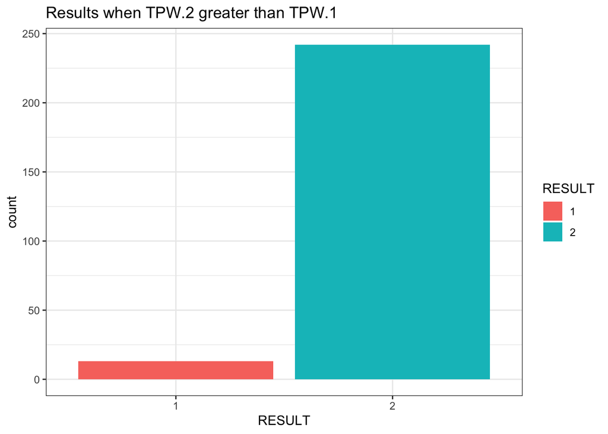

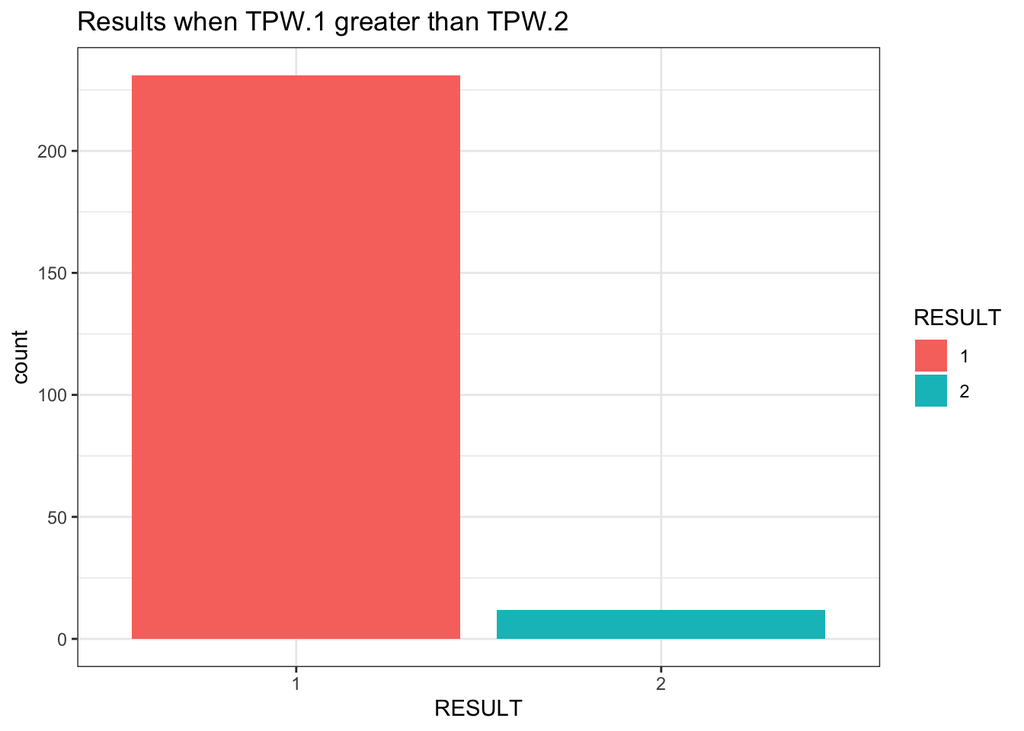

After TPW remove from data set, number of NA values are like below.

```
## ST2.1 ST3.1 ST4.1 ST5.1 ST2.2 ST3.2 ST4.2 ST5.2
##     3   319   662   755     3   319   662   755
```

There is 350 unique player on this data set. So using players as predictor is not good idea because there are 350 levels, this is not convenient for modeling. Also, our aim in this project is predict result by using player performance like ACE, BPC etc., and show the most important statistics. Because of that PLAYER1 and PLAYER2 columns are removed from data set.

After missing data cleaning and imputation, we have 816 observations and 28 variables.

```
##  ROUND   RESULT      FSP.1          FSW.1            SSP.1
##  1:409   1:406   Min.   :40.0   Min.   :0.5294   Min.   :14.00
##  2:197   2:410   1st Qu.:57.0   1st Qu.:1.1780   1st Qu.:32.00
##  3:107           Median :63.0   Median :1.3586   Median :37.00
##  4: 55           Mean   :62.8   Mean   :1.3451   Mean   :37.25
##  5: 27           3rd Qu.:68.0   3rd Qu.:1.5241   3rd Qu.:43.00
##  6: 14           Max.   :86.0   Max.   :2.6000   Max.   :60.00
##  7:  7
##      SSW.1             ACE.1             DBF.1             WNR.1
##  Min.   :0.07692   Min.   :0.00000   Min.   :0.00000   Min.   :0.0000
##  1st Qu.:0.44444   1st Qu.:0.06897   1st Qu.:0.06061   1st Qu.:0.7222
##  Median :0.56667   Median :0.15895   Median :0.11765   Median :1.0000
##  Mean   :0.56579   Mean   :0.19456   Mean   :0.13461   Mean   :1.0019
##  3rd Qu.:0.68750   3rd Qu.:0.26923   3rd Qu.:0.18750   3rd Qu.:1.2632
##  Max.   :1.40000   Max.   :1.12000   Max.   :0.66667   Max.   :3.0769
##
##      UFE.1           BPC.1            BPW.1            NPA.1
##  Min.   :0.000   Min.   :0.0000   Min.   :0.0000   Min.   :0.03704
##  1st Qu.:0.717   1st Qu.:0.1765   1st Qu.:0.0625   1st Qu.:0.38054
##  Median :1.000   Median :0.3125   Median :0.1290   Median :0.61678
##  Mean   :1.042   Mean   :0.3331   Mean   :0.1438   Mean   :0.65085
##  3rd Qu.:1.349   3rd Qu.:0.4600   3rd Qu.:0.2105   3rd Qu.:0.84053
##  Max.   :3.167   Max.   :1.2667   Max.   :0.5000   Max.   :2.12195
##
##      NPW.1            FSP.2           FSW.2            SSP.2
##  Min.   :0.0000   Min.   :39.00   Min.   :0.4286   Min.   : 7.00
##  1st Qu.:0.2353   1st Qu.:57.00   1st Qu.:1.1761   1st Qu.:32.00
##  Median :0.3913   Median :62.00   Median :1.3438   Median :38.00
##  Mean   :0.4261   Mean   :62.51   Mean   :1.3486   Mean   :37.51
##  3rd Qu.:0.5520   3rd Qu.:68.00   3rd Qu.:1.5034   3rd Qu.:43.00
##  Max.   :4.1333   Max.   :93.00   Max.   :2.6512   Max.   :61.00
##
##      SSW.2            ACE.2             DBF.2            WNR.2
##  Min.   :0.0625   Min.   :0.00000   Min.   :0.0000   Min.   :0.000
##  1st Qu.:0.4515   1st Qu.:0.05882   1st Qu.:0.0625   1st Qu.:0.750
##  Median :0.5769   Median :0.15385   Median :0.1200   Median :1.000
##  Mean   :0.5758   Mean   :0.18132   Mean   :0.1432   Mean   :1.007
##  3rd Qu.:0.6875   3rd Qu.:0.27273   3rd Qu.:0.2000   3rd Qu.:1.263
##  Max.   :1.4000   Max.   :0.93750   Max.   :0.7692   Max.   :2.455
##
##      UFE.2           BPC.2            BPW.2            NPA.2
##  Min.   : 0.00   Min.   :0.0000   Min.   :0.0000   Min.   :0.0000
##  1st Qu.:16.00   1st Qu.:0.1852   1st Qu.:0.0625   1st Qu.:0.3741
##  Median :26.00   Median :0.3093   Median :0.1263   Median :0.5938
##  Mean   :27.71   Mean   :0.3292   Mean   :0.1454   Mean   :0.6467
##  3rd Qu.:37.00   3rd Qu.:0.4487   3rd Qu.:0.2105   3rd Qu.:0.8614
##  Max.   :96.00   Max.   :1.1667   Max.   :0.5385   Max.   :2.2903
##
##      NPW.2             TOURNAMENT  GENDER
##  Min.   :0.0000   AusOpen   :252   F:451
##  1st Qu.:0.2353   FrenchOpen:252   M:365
##  Median :0.3913   USopen    : 76
##  Mean   :0.4310   Wimbledon :236
##  3rd Qu.:0.5838
##  Max.   :2.2667
##
```

## Statistical Modelling

### Train-Test Data Set Preparation

GrandSlam data set splited by 20% test and 80% training by random selection. Before modelling, numeric variables in the train and test data set should be scaled. Firstly, train set is scaled and then, by using train set mean and standart deviation test set should be scaled too. Test and train sets are scaled after splitting, because, test observations should not be effect anything on the train data set in order to maintain integrity of model evaluation. After scale the train data set summary is like below.

```
##      FSP.1              FSW.1              SSP.1              SSW.1
##  Min.   :-2.85592   Min.   :-2.96049   Min.   :-2.95000   Min.   :-2.56650
##  1st Qu.:-0.71350   1st Qu.:-0.58376   1st Qu.:-0.68074   1st Qu.:-0.70893
##  Median : 0.04265   Median : 0.06331   Median :-0.05039   Median : 0.01287
##  Mean   : 0.00000   Mean   : 0.00000   Mean   : 0.00000   Mean   : 0.00000
##  3rd Qu.: 0.67277   3rd Qu.: 0.65108   3rd Qu.: 0.70603   3rd Qu.: 0.67264
##  Max.   : 2.94122   Max.   : 4.51758   Max.   : 2.84922   Max.   : 4.72261
##
##      ACE.1             DBF.1             WNR.1              UFE.1
##  Min.   :-1.1885   Min.   :-1.3064   Min.   :-2.32873   Min.   :-2.12497
##  1st Qu.:-0.7576   1st Qu.:-0.7032   1st Qu.:-0.64986   1st Qu.:-0.68411
##  Median :-0.1831   Median :-0.1710   Median :-0.03133   Median :-0.08223
##  Mean   : 0.0000   Mean   : 0.0000   Mean   : 0.00000   Mean   : 0.00000
##  3rd Qu.: 0.4355   3rd Qu.: 0.4808   3rd Qu.: 0.60683   3rd Qu.: 0.65263
##  Max.   : 5.5674   Max.   : 5.1276   Max.   : 4.74018   Max.   : 4.48203
##
##      BPC.1             BPW.1             NPA.1              NPW.1
##  Min.   :-1.6543   Min.   :-1.3785   Min.   :-1.71592   Min.   :-1.5404
##  1st Qu.:-0.7731   1st Qu.:-0.8066   1st Qu.:-0.73800   1st Qu.:-0.6498
##  Median :-0.1201   Median :-0.1477   Median :-0.07184   Median :-0.1154
##  Mean   : 0.0000   Mean   : 0.0000   Mean   : 0.00000   Mean   : 0.0000
##  3rd Qu.: 0.6368   3rd Qu.: 0.6436   3rd Qu.: 0.52165   3rd Qu.: 0.4581
##  Max.   : 4.5646   Max.   : 3.3398   Max.   : 4.07880   Max.   :13.1847
##
##      FSP.2              FSW.2              SSP.2              SSW.2
##  Min.   :-2.87818   Min.   :-3.29061   Min.   :-3.75999   Min.   :-2.73045
##  1st Qu.:-0.66388   1st Qu.:-0.65733   1st Qu.:-0.69151   1st Qu.:-0.67829
##  Median :-0.04879   Median : 0.01286   Median : 0.04492   Median : 0.01683
##  Mean   : 0.00000   Mean   : 0.00000   Mean   : 0.00000   Mean   : 0.00000
##  3rd Qu.: 0.68931   3rd Qu.: 0.56673   3rd Qu.: 0.65862   3rd Qu.: 0.59428
##  Max.   : 3.76473   Max.   : 4.71114   Max.   : 2.86792   Max.   : 4.38447
##
##      ACE.2             DBF.2             WNR.2              UFE.2
##  Min.   :-1.1892   Min.   :-1.2639   Min.   :-2.42960   Min.   :-1.8099
##  1st Qu.:-0.7967   1st Qu.:-0.7009   1st Qu.:-0.62135   1st Qu.:-0.6967
##  Median :-0.1773   Median :-0.2373   Median :-0.01859   Median :-0.1073
##  Mean   : 0.0000   Mean   : 0.0000   Mean   : 0.00000   Mean   : 0.0000
##  3rd Qu.: 0.5377   3rd Qu.: 0.4472   3rd Qu.: 0.62434   3rd Qu.: 0.6130
##  Max.   : 4.8818   Max.   : 5.4487   Max.   : 2.95972   Max.   : 4.4765
##
##      BPC.2              BPW.2             NPA.2             NPW.2
##  Min.   :-1.67495   Min.   :-1.3355   Min.   :-1.7247   Min.   :-1.6260
##  1st Qu.:-0.73182   1st Qu.:-0.7484   1st Qu.:-0.7236   1st Qu.:-0.7272
##  Median :-0.07888   Median :-0.1613   Median :-0.1348   Median :-0.1630
##  Mean   : 0.00000   Mean   : 0.0000   Mean   : 0.0000   Mean   : 0.0000
##  3rd Qu.: 0.59447   3rd Qu.: 0.5913   3rd Qu.: 0.5623   3rd Qu.: 0.5343
##  Max.   : 4.37684   Max.   : 3.7223   Max.   : 4.4656   Max.   : 7.0792
##
##  ROUND   RESULT       TOURNAMENT  GENDER
##  1:331   1:332   AusOpen   :204   F:361
##  2:153   2:321   FrenchOpen:197   M:292
##  3: 84           USopen    : 61
##  4: 46           Wimbledon :191
##  5: 22
##  6: 12
##  7:  5
```

### Support Vector Machine Modeling

SVM is used to predict the RESULT of the tennis matches on this project. As a cross validation method, k-fold cv is used for k equals 10. This cv is made by using “caret” package in r.

```
## [1] "Accuracy: 0.94478527607362"
```

```
## Confusion Matrix and Statistics
##
##           Reference
## Prediction  1  2
##          1 69  4
##          2  5 85
##
##                Accuracy : 0.9448
##                  95% CI : (0.8978, 0.9744)
##     No Information Rate : 0.546
##     P-Value [Acc > NIR] : <2e-16
##
##                   Kappa : 0.8885
##
##  Mcnemar's Test P-Value : 1
##
##             Sensitivity : 0.9324
##             Specificity : 0.9551
##          Pos Pred Value : 0.9452
##          Neg Pred Value : 0.9444
##              Prevalence : 0.4540
##          Detection Rate : 0.4233
##    Detection Prevalence : 0.4479
##       Balanced Accuracy : 0.9437
##
##        'Positive' Class : 1
##
```